# child1

Clueless

March 30, 2014

## Démographie régionale

Avec 8280 km², l’Alsace est la plus petite des régions de la France métropolitaine, mais elle fait partie des plus densément peuplée (225 hab./km²) derrière l’Ile de Fance et le Nord.

Elle comprend deux départements, le Bas-Rhin (67) et le Haut-Rhin (68). Elle fait partie de la région du Rhin supérieur avec comme le land du Bade-Wurtemberg et le canton suisse de Bâle avec qui elle partage une frontière commune.

Au 1er janvier 2012, l’Alsace compte 1 859 869 habitants.

Sur la période 1982-2011, la population régionale a augmenté de 286 300 habitants, soit une croissance annuelle moyenne de quelque 10 000 personnes. Ce dynamisme démographique est avant tout lié à l’excédent des naissances sur les décès. En trente ans, ce solde naturel contribue à hauteur de 80 % à la hausse totale de la population.

Sources:

- [INSEE Recensement](http://www.insee.fr/fr/ppp/bases-de-donnees/recensement/populations-legales/france-regions.asp?annee=2012)).
- [INSEE Régions](http://www.insee.fr/fr/regions/alsace/default.asp?page=faitsetchiffres/presentation/presentation.htm)
- [INSEE Thèmes](http://www.insee.fr/fr/themes/document.asp?ref_id=20665)

## Découpage de la région en territoires de santé

La loi Hôpital Patients Santé et territoires (HPST) prévoit le découpage de chaque région en “territoires de santé” (article L1434-11 du code de la santé publique).

L’Alsace est découpée, du nord au sud, en 4 territoires de santé:

- Le territoire 1 (Haguenau)
- Le territoire 2 (Strasbourg)
- Le territoire 3 (Colmar)
- Le territoire 4 (Mulhouse)

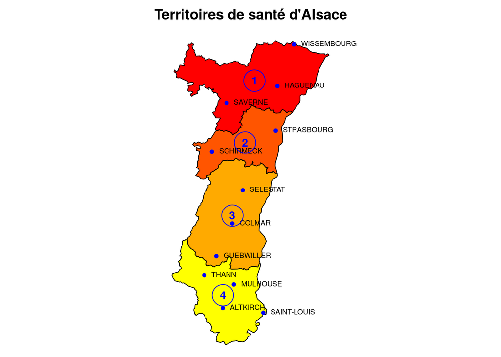

Population

# Offre de soins régionale

### Etablissements d’Alsace ayant une autorisation de structure d’urgence

Sites gégraphiques d’accueil des urgences:

- Territoire de santé 1

  ```
  - CH de Wissembourg (SU polyvalent + SMUR)
  - CH de Haguenau (SU polyvalent + SMUR)
  - CH de Saverne  (SU polyvalent + SMUR)
  ```

- Territoire de santé 2

  ```
  - CHU de Strasbourg
          - NHC (SU adulte)
          - Hôpital de Hautepierre (SU adulte + SU pédiatrique)
          - Pôle logistique (SAMU + SMUR + Hélismur)
  - Clinique Sainte Odile (SU polyvalent)
  - Clinique Sainte Anne (SU polyvalent)
  - Clinique du Diaconat (SU Mains)
  ```

- Territoire de santé 3

  ```
  - CH de Sélestat (SU polyvalent + SMUR)
  - CH de Colmar
          - Hôpital Pasteur (SU polyvalent + SMUR)
          - Hôpital du parc (SU pédiatrique)
  - CH de Guebwiller (SU polyvalent)
  ```

- Territoire de santé 4

  ```
  - CH de Thann (SU polyvalent)
  - CH d'Altkirch (SU polyvalent)
  - CH de Mulhouse
          - Hôpital Emile Muller (SU polyvalent + SAMU + SMUR + Hélismur)
          - Hôpital du Hasenrain (SU pédiatrique)
  - Clinique des 3 frontières (SU polyvalent)
  - Clinique du Diaconat-Fonderie (SU polyvalent)
  - Clinique du Diaconat-Roosvelt (SU Mains)
  ```

En 2014 tous ces établissements ont fourni des RPU sauf le CH THANN.